# Uma Introdução à Modelagem de Equações Estruturais

Guilherme L. de Oliveira

07 de outubro de 2016

## Introdução

Nesta oportunidade trago para o grupo uma discussão a respeito do que se conhece como **modelagem de equações estruturais** (SEM - do inglês *Structural Equation Modeling*). Mesmo “conhecendo” (reparem que isto é diferente de “dominar”!) as técnicas estatística envolvidas na análise, este assunto é novo pra mim. Trata-se de uma modelagem conjunta de relações causais e determinísticas entre variáveis mensuráveis e latentes usando técnicas de estatística multivariada. O objetivo principal é a comprovação de conhecimentos teórico-subjetivos estabelecidos sobre as relações causais presentes no modelo estabelecido *a priori*. É preciso salientar que este material não é livre de erros e equívocos. Também, devo mencionar que os trabalhos de [Amorim *et. al* (2012)](https://repositorio.ufba.br/ri/bitstream/ri/17684/1/ebook_SEM_2012.pdf), [León e Fachel (2011)](http://www.lume.ufrgs.br/bitstream/handle/10183/31630/000784196.pdf) e [Hox e Bechger (1998)](http://joophox.net/publist/semfamre.pdf) foram utilizados como referências principais para o que é apresentado aqui, sobretudo as figuras e os exemplos.

## O que vem a ser *SEM*?

Modelagem de equações estruturais é uma técnica de análise estatística multivariada muito geral que é amplamente utilizada em ciências sociais e comportamentais. **Geralmente envolve uma combinação de técnicas de análise fatorial confirmatória e regressão linear múltipla com o objetivo de analisar a relação estrutural/causal entre grandezas mensuráveis e construtos latentes**. É conhecida por vários nomes como, por exemplo, análise de estruturas de covariância, modelos LISREL (*LInear Structural RELations*) e modelagem “causal”.

Comparado à análise de regressão e análise fatorial, a SEM é um campo relativamente novo. Ela tem suas raízes na análise de caminhos (**path analysis**) desenvolvida pelo geneticista Sewall Wright em 1921, porém suas formas modernas e ampla utilização surgiram com os avanços computacionais ocorridos a partir das décadas de 1960 e 1970. É costume começar a SEM desenhando um diagrama de caminhos como propôs Sewall Wright em 1921. Por ser recente, a metodologia ainda está em desenvolvimento, e até mesmo conceitos fundamentais estão sujeitos a contestação e revisão pelos usuários frequentes.

## Para que é utilizada?

SEM pode ser usado conceitualmente para responder a qualquer pergunta de pesquisa envolvendo a observação direta ou indirecta de uma ou mais variáveis independentes ou uma ou mais variáveis dependentes. No entanto, o principal objetivo do SEM é determinar e validar um processo causal ou modelo proposto. Portanto, **SEM é uma técnica de confirmação** de algum estudo de pesquisa **em vez da exploraração** ou explicação um algum fenômeno. Isto é, um investigador é mais propenso a usar a SEM para determinar se um determinado modelo teórico (*hipotético*) é válido em vez de usá-la para “encontrar” um modelo adequado. Neste sentido, as relações mostradas na SEM representam as hipóteses *a priori* dos pesquisadores com relação a *construtos teóricos*, representados por fatores latentes.

Como em qualquer outro teste ou modelo, temos uma amostra e queremos dizer algo sobre a população que gerou a amostra. Nós temos uma matriz de covariância que serve como nosso conjunto de dados, a qual é baseada na amostra recolhida. **A questão empírica do SEM é, portanto, se o modelo proposto produz uma matriz de covariâncias que é consistente com a matriz covariâncias amostral**.

Em SEM, o interesse geralmente se concentra nos fatores latentes (por exemplo, variáveis psicológicas abstratas como “inteligência” ou “propensão ao suicídio”) em vez de se concentrar nas variáveis manifestas (grandezas mensuráveis/observáveis) determinadas por esses fatores.

Uma vez que é preciso especificar *a priori* um modelo que será submetido a testes de validação, há muitas perguntas que podem ser respondidas usando a SEM. Ela pode nos dizer se um determinado modelo é adequado ou não. Estatísticas de bondade de ajuste podem ser calculadas para nos dizer se o seu modelo é apropriado ou se este precisa de uma revisão mais aprofundada. SEM também pode ser usado para comparar várias teorias que são especificadas *a priori*.

SEM permite quantificar a variância das variáveis dependentes - tanto manifestas quanto latentes - que é explicado pelas variáveis independentes no modelo. Pode também ser usada para verificar a significância de cada variável medida.

Diferenças entre grupos taMbém podem ser averiguadas através da SEM. Modelos de equações estruturais podem ser ajustados separadamente para diferentes grupos e os resultados podem ser comparados. Além disso, tanto efeitos aleatórios quanto efeitos fixos podem ser incluídos nos modelos e, assim, técnicas de modelagem hierárquicas podem ser consideradas nas análises.

## Algumas vantagens

A SEM, enquanto técnica multivariada, tem como base um conjunto de relações, sendo cada uma com variáveis dependentes e independentes, apresentando algumas vantagens em relação às demais técnicas, a citar:

- Permite a incorporação dos erros de medição no processo de estimação do modelo de maneira simples;
- Consiste na estimação simultânea de diversas relações de dependência interrelacionadas;
- Permite que uma variável dependente em uma etapa do modelo se torne uma variável independente nas subsequentes relações de dependência;
- A capacidade de definir suposições elaboradas com base no suporte téorico e incluí-las no modelo dá à SEM flexibilidade no exame de questões analíticas dos dados.

## Algumas Limitações e Suposições da SEM

Como a SEM é uma técnica de confirmação, **tudo deve ser planejado anteriormente**. Um modelo completo deve ser especificado *a priori* e então testado com base na amostra das variáveis medidas. **Deve-se saber o número de parâmetros a serem estimados** - incluindo covariâncias, “coeficientes de caminho” e variâncias. Além disso, **todas as relações que deseja especificar no modelo devem ser sabidas**. Então, e somente então, se pode iniciar as análises.

Com relação as suposições, podemos citar:

- distribuição normal multivariada para os termos de erro (há estudos recentes sobre a flexibilização desta suposição!);
- independência dos termos de erros;
- linearidade entre as variáveis endógenas e exógenas;
- sequência: deve haver uma relação de causa e efeito entre as variáveis endógenas e exógenas, e uma causa tem de ocorrer antes do evento;
- *outlier*: os dados devem ser livres de *outliers* pois estes afetam a significância do modelo;
- relacionamento não-espúrio: covariâncias observadas devem ser verdadeiras (não devidas ao acaso);
- modelo deve estar devidamente identificado;
- tamanho amostral: uma regra bastante comum é ter uma amostra de 10 a 20 vezes maior que o número variáveis;
- dados intervalares.

## Construção do modelo teórico

Para construir um modelo de equações estruturais parte-se de um modelo teórico previamente definido que permitirá determinar as múltiplas relações de dependência (ou *relações causais*) entre as variáveis do modelo. **Um modelo teórico consiste em um conjunto sistemático de relações que fornecem explicações consistentes e abrangentes dos fenômenos**. O modelo teórico que serve de apoio à construção de um modelo de equações estruturais não é restrito a uma teoria definida no âmbito acadêmico, mas pode ser alicerçado na experiência e na prática obtidas a partir da observação do comportamento real. A idéia geral da SEM pode ser representada pelo esquema apresentado na Figura 1.

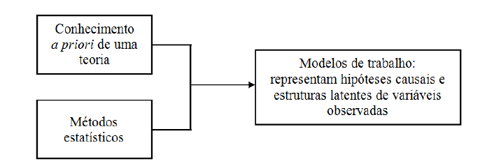

Figura 1: Filosofia da Modelagem com Equações Estruturais. [fonte: Amorim et. al (2012)].

Este método é preferido neste tipo de pesquisa porque estima a dependência múltipla e as interligações entre todas as quantidades envolvidas em uma única análise.

A Figura 2 é apresentada com o intuito de nos situarmos e nos motivarmos a respeito do tipo de estrutura que se pode modelar usando os modelos de equações estruturais. Há de se salientar que este exemplo representa um modelo bastante complexo com várias relações causais. Neste ponto, não precisamos nos atentar ao que significa cada quantidade e forma no diagrama. Isto será feito na próxima seção. Usemos a Figura 2 apenas para discutir a importância da SEM por tornar possível a resolução de problemas complexos como o que ela apresenta.

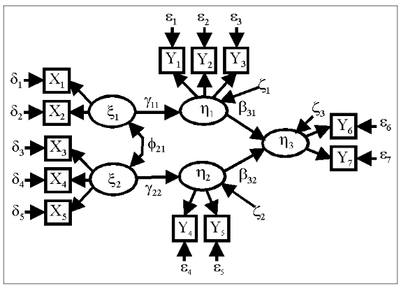

Figura 2: Exemplo de estrutura que pode ser modelada usando a SEM. As relações causais são estabelecidas com base em conhecimentos prévios a respeito do fenômeno em estudo. [fonte: [SEMNET](http://www2.gsu.edu/~mkteer/sem2.html)].

## Representação gráfica do modelo teórico (*path diagram*):

Como em SEM, em geral, os modelos teóricos são bastante complexos, muitos pesquisadores acham mais conveniente retratá-los primeiramente na forma de um diagrama. O chamado diagrama de caminhos (*path diagram*) permite uma rápida visualização das relações de interdependência consideradas no modelo teórico. A exibição visual facilita a interpretação por parte do pesquisador.

O diagrama de caminhos é representado por um conjunto de figuras geométricas e setas que servem para evidenciar o tipo de variável (observada ou latente) e o tipo de relação entre elas. A Figura 3 ilustra as convenções usadas para a representação das relações entre um construto e uma ou mais variáveis de medição e a relação entre construtos segundo [Amorim *et. al* (2012)](https://repositorio.ufba.br/ri/bitstream/ri/17684/1/ebook_SEM_2012.pdf).

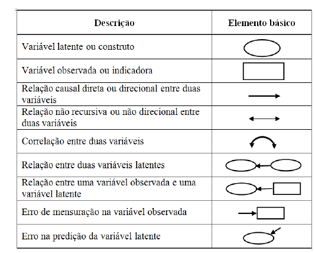

Figura 3: Elementos básicos utilizados na construção de um diagrama de caminhos. [fonte: Amorim et. al (2012)].

Quando duas variáveis não estão ligadas através de uma seta não implica necessariamente que uma não afete a outra. Essa relação pode ocorrer indiretamente, podendo ser identificada através de caminhos mais complexos.

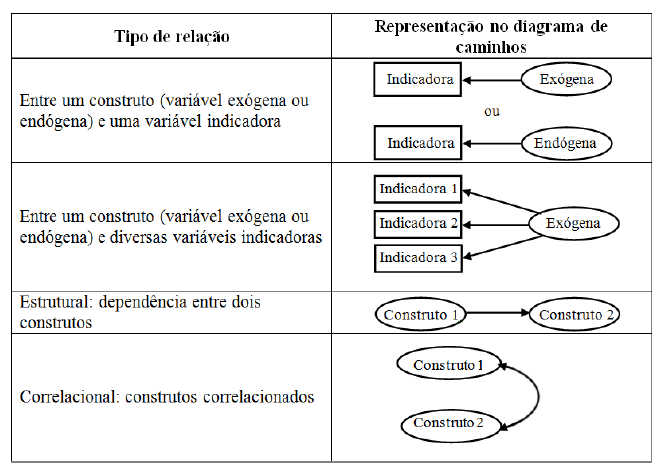

Figura 4: Relações téoricas em SEM. [fonte: Amorim et. al (2012)].

Na Figura 5 são ilustrados três tipos de relação que podem ser descritos através de um diagrama de caminhos e suas correpondentes equações.

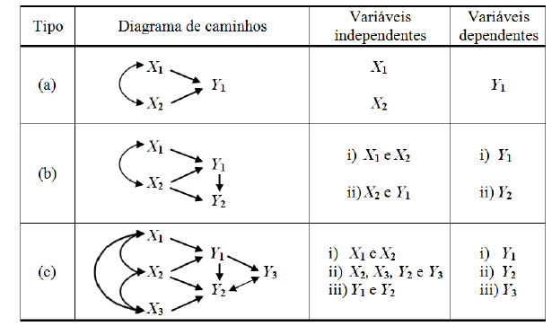

Figura 5: Relações causais representadas em diagramas de caminhos. [fonte: Amorim et. al (2012)].

## Especificação do modelo de equações estruturais (SEM)

### Sub-modelos da SEM

Um modelo de equações estruturais é dividido em duas partes:

- *modelo de medição/mensuração*: representa a teoria de que especifica como variáveis manifestas se juntam para representar a teoria;
- *modelo estrutural*: representa a teoria que mostra como os construtos estão relacionadas com outros construtos.

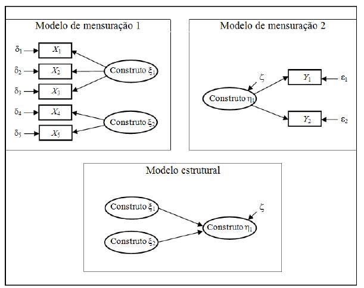

Figura 6: Sub-modelos de um modelo convencional em SEM. [fonte: Amorim et. al (2012)].

### Especificação matemática do modelo de mensuração e do modelo estrutural no contexto de *variáveis endógenas observadas*

Os parâmetros estruturais a serem modelados podem ser representados pelo vetor $\Omega = (\mathbb{B},\Gamma,\Psi,\Phi)$. Considere $E(x)= \mu_x$ o vetor de médias para x e $E(\zeta) = 0$. Assume-se que $(I - \mathbb{B})$ não é singular, então sua inversa pode ser definida. Com isto,

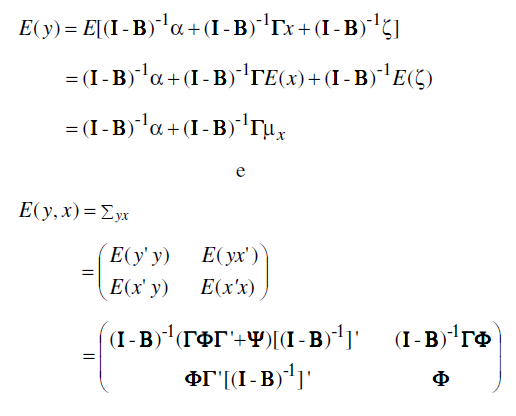

Portanto, a modelagem por equações estruturais representa o vetor de média e a matriz de covariância das quantidades X e Y. Essa estrutura é definida em termos dos parâmetros do modelo. **Na prática, a matriz de covariância serve como o conjunto de dados a serem analisados**. Usualmente para simplificar as equações estruturais, considera-se o uso de variáveis centradas em sua média.

A especificação dos elementos da matriz $\mathbb{B}$ permitirá a distinção entre duas classificações analíticas dos modelos de caminhos (*path analysis*): **(a) recursivos** e **(b) não recursivos ou simultâneos**. Para ilustrar através de diagramas de caminhos a diferença entre esses dois tipos de modelos, considere as Figuras 7 e 8.

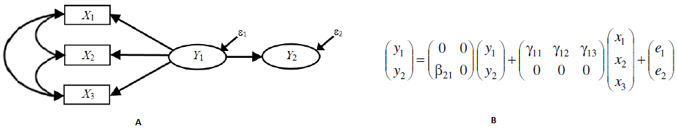

Figura 7: Exemplo de um modelo recursivo - em diagrama (A) e matricialmente (B) [fonte: Amorim et. al (2012)].

Nos *modelos não recursivos*, por sua vez, existe um *loop* entre variáveis endógenas do modelo, o que implica que $\mathbb{B}$ não é triangular inferior. Além disso, muitas vezes considera-se a existência de um termo de covariância entre os ruídos das variáveis endógenas envolvidas no *loop*. Nesse caso, $\Psi$ é uma matriz simétrica, com elementos não nulos fora da diagonal principal. Este tipo de modelo implica em uma especificação dinâmica do modelo estrutural, que pode causar problemas de instabilidade do procedimento de estimação.

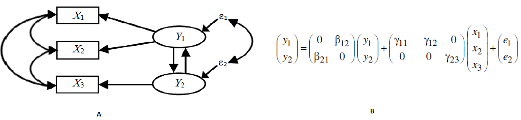

Figura 8: Exemplo de um modelo não-recursivo - em diagrama (A) e matricialmente (B) [fonte: Amorim et. al (2012)].

#### Estimação do modelo de equações estruturais com *variáveis endógenas observadas*

O procedimento de estimação em SEM tem como objetivo obter estimativas para o vetor de parâmetros $\Omega$, denominado $\hat{\Omega}$, que minimizem uma função de discrepância $F(S,\hat{\Sigma})$. Esta função é um escalar que mensura a distância entre a matriz de covariância amostral, $S$, e a matriz de covariância baseada nas estimativas obtidas pelo modelo (matriz de covariância ajustada), $\hat{\Sigma}=\Sigma(\hat{\Omega})$.

Os parâmetros a serem estimados pelo modelo no caso de variáveis endógenas observadas são:

- as variâncias e covariâncias das variáveis exógenas em $\Phi$;
- as variâncias e covariâncias dos termos de ruído em $\Psi$;
- os coeficientes de regressão em $\mathbb{B}$ e $\Gamma$.

Os dois métodos de estimação mais comumente utilizados são o método de máxima verossimilhança e os mínimos quadrados generalizados ou parciais. **A estimação é feita de forma iterativa**. Mais detalhes em [Amorim *et. al* (2012)](https://repositorio.ufba.br/ri/bitstream/ri/17684/1/ebook_SEM_2012.pdf). Diversos critérios de bondade de ajuste são apresentados na Literatura.

Uma vez que os parâmetros do modelo foram estimados, a matriz de covariância ajustada pode então ser comparado a uma matriz de covariância empírica. Se as duas matrizes forem compatíveis, em seguida, o modelo estrutural pode ser considerado uma explicação plausível para as relações entre as medidas envolvidas.

### Especificação matemática do modelo de mensuração e do modelo estrutural no contexto de *variáveis endógenas latentes*

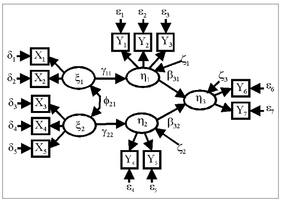

o qual pode ser representado pelas equações

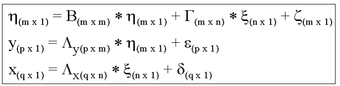

Neste contexto, a estimação também se baseia nas matrizes de covariância e pode ser feita utilizando os métodos de máxima verossimilhança e dos mínimos quadrados generalizados [veja, por exemplo, [Stevens (2009)](http://pages.uoregon.edu/stevensj/workshops/sem_slides6.pdf) e [Amorim *et. al* (2012)](https://repositorio.ufba.br/ri/bitstream/ri/17684/1/ebook_SEM_2012.pdf)].

### Sobre a identificabilidade do modelo estrutural:

O problema de identificabilidade do modelo refere-se à existência de solução única na estimação dos parâmetros. Um modelo é dito identificado quando teoricamente é possível obter uma única estimativa para cada conbinação dos seus parâmetros. Dentro da abordagem com equações estruturais, a definição de identificabilidade está relacionada à modelagem da estrutura de covariância. Assim, a identificabilidade do modelo geralmente ocorre quando o número de elementos da matriz de covariância entre as variáveis observadas for maior ou igual ao número de parâmetros a serem estimados.

Os modelos identificados que possuem o mesmo número de parâmetros e observações são chamados de exatamente identificados, enquanto que os modelos que possuem menos parâmetros que observações são chamados de super-identificados.

Existem na literatura algumas regras para verificação da identificabilidade do modelo. Veja detalhes em [Amorim *et. al* (2012)](https://repositorio.ufba.br/ri/bitstream/ri/17684/1/ebook_SEM_2012.pdf).

## Softwares

Existem diversos programas estatísticos que implementam os modelos de equações estruturais, dentre eles

- AMOS (*Analysis of Moment Structures*): é um módulo de extensão do programa estatístico SPSS desenvolvido para aplicação de SEM (pago);
- LISREL (*Linear Structural Relationships*): o LISREL é considerado sinônimo de SEM por ter sido desenvolvido especificamente para o emprego desta técnica e por ser o pioneiro em sua aplicação (pago);
- MPLUS (pago);
- SAS (pago);
- MX GRAPH (gratuito);
- R: o pacote [SEM](https://cran.r-project.org/web/packages/sem/index.html) do R possibilita ajuste de modelos de equações estruturais com variáveis observadas e latentes através do uso da técnica da máxima verossimilhança, assumindo multinormalidade (gratuito).

## SEM na internet

Pesquisadores trabalhando com modelagem de equações estruturais geralmente mantém páginas de discussão sobre o assunto na web. Uma boa página para iniciantes é a lista de discussão [SEMNET](http://www2.gsu.edu/~mkteer/semfaq.html) criada por Ed Rigdon, rofessor de marketin na Universidade do Estado da Geórgia, EUA. Obviamente, há diversas outras páginas da web de fácil acesso tratando de SEM.

# Enfim, vejamos uma aplicação da SEM!

Para ilustração da aplicabilidade dos métodos discutidos neste encontro são apresentadas partes das análises de [Amorim *et. al* (2012)](https://repositorio.ufba.br/ri/bitstream/ri/17684/1/ebook_SEM_2012.pdf) usando esta metodologia num estudo cujo intuito era **descrever a relação entre o estado antropométrico, as condições socioeconômicas, a qualidade do lar e o desenvolvimento cognitivo de 320 crianças de 20 a 48 meses de idade** nascidas no período de janeiro a julho de 1999 na cidade de Salvador, Bahia.

O desenvolvimento cognitivo (IDM) das crianças foi medido utilizando-se a escala de Bayley e as características do lar (HOME) foram mensuradas pelos objetos nele existentes. Para avaliar o estado antropométrico, utilizaram-se os escores antropométricos peso/idade e altura/idade, além do peso ao nascer.

A SEM foi utilizado nessa aplicação para:

- definir construtos (variáveis latentes) que representem características do ambiente em que a criança vive, além de características relacionais e nutricionais da criança;
- avaliar o impacto desses construtos no desenvolvimento cognitivo da criança.

Para a implementação do SEM foram utilizadas as seguintes variáveis: responsividade emocional e verbal (homei), ausência de punição e restrição (homeii), organização do ambiente físico e temporal (homeiii), disponibilidade de brinquedos (homeiv), envolvimento materno com a criança (homev), oportunidade de variação na estimulação (homevi), escore altura/idade (haz), peso ao nascer, em quilogramas (peso), sexo, idade em meses (idmes), e escore do desenvolvimento cognitivo infantil (IDM).

[figure not shown]

Figura 10: Análise fatorial confirmatória para desenvolvimento cognitivo em menores de 48 meses. [fonte: Amorim et. al (2012)].

Aqui o modelo pode ser definido pelas seguintes equações:

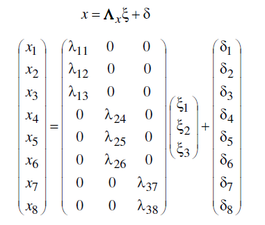

Agora, prossegue-se com a modelagem de equação estruturais incluindo a variável endógena IDM. A variável endógena neste estudo é observada e mensurada diretamente, referindo-se ao escore de desempenho cognitivo da criança (IDM) e é modelada pela equação $IDM=\gamma_1\xi_1+\gamma_2\xi_2+\gamma_3\xi_3+\beta_1 SEXO+\beta_2 IDADE+\zeta_1.$

Os resultados são mostrados na Figura 11.

[figure not shown]

Figura 11: Modelo de equações estruturais para desenvolvimento cognitivo em menores de 48 meses. [fonte: Amorim et. al (2012)].

Um outro modelo mais complexo também foi ajustado, mas não será apresentado aqui [veja em [Amorim *et. al* (2012)](https://repositorio.ufba.br/ri/bitstream/ri/17684/1/ebook_SEM_2012.pdf)]. Na Figura 12, podemos ver a Tabela contendo as medidas de bondade de ajuste para os dois modelos. Segundo os autores, ambos os modelos se mostraram bem-ajustados.

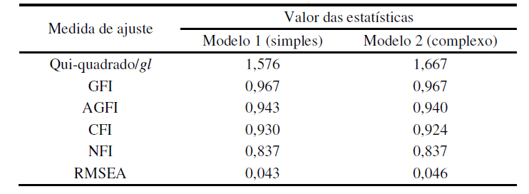

Figura 12: Tabela contento os critérios de bondade de ajuste para os dois SEMs sobre desenvolvimento cognitivo. [fonte: Amorim et. al (2012)].

## Considerações Finais

Há muito o que estudar sobre o assunto! Não foi apresentado nenhum código ou exemplo explíto em algum software, mas nas referências dadas é possível ter acesso a alguns exemplos. Espera-se que com esta discussão ao menos a ideia básica do método de modelagem de equações estruturais tenha sido esclarecido e, além disso, que nosso conhecimento tenha sido enriquecido neste sentido.

## Referências

- [Amorim, L.D.A.F., Fiaccone, R.L., Santos, C.A.S.T., Moraes, L.T.L.P., de Oliveira, N.F., Oliveira, S.B. e dos Santos, T.N.L. (2012) Modelagem com Equações Estruturais: Princípios Básicos e Aplicações. Universidade Federal da Bahia and Universidade Estadual de Feira de Santana](https://repositorio.ufba.br/ri/bitstream/ri/17684/1/ebook_SEM_2012.pdf)
- [Ed Rigdon, Frequently Asked Questions (FAQ) about structural equation modeling: SEMNET](http://www2.gsu.edu/~mkteer/semfaq.html)
- [Hox, J.J. e Bechger, T.M. (1998) An Introduction to Structural Equation Modeling. Family Science Review, 11, 354-373.](http://joophox.net/publist/semfamre.pdf)
- [León, D.A.D. e Fachel, J.M.G. (2011) Análise Fatorial Confirmatória através dos Softwares R e Mplus. An'alise Fatorial Confirmat'oria atrav'es dos Softwares R e Mplus. Monografia de graduação em Estatística. Universidade Federal do Rio Grande do Sul.](http://www.lume.ufrgs.br/bitstream/handle/10183/31630/000784196.pdf)
- [SEM: A R package for Structural Equation Models](https://cran.r-project.org/web/packages/sem/index.html)
- [Stevens, J. (2009) Structural Equation Modeling (SEM): A Workshop Presented to the College of Education. University of Oregon](http://pages.uoregon.edu/stevensj/workshops/sem_slides6.pdf)

**OBRIGADO!**